# Sessão 5.1: Introdução à Gramática dos Gráficos com ggplot2

### 1.2.3. Componente 3: Geometrias (geom_)

As funções geom_ definem como os dados serão desenhados. Cada geom_ corresponde a um tipo de gráfico (e.g., geom_point() para gráficos de dispersão, geom_bar() para gráficos de barras). Adicionamos as geometrias usando o operador +.

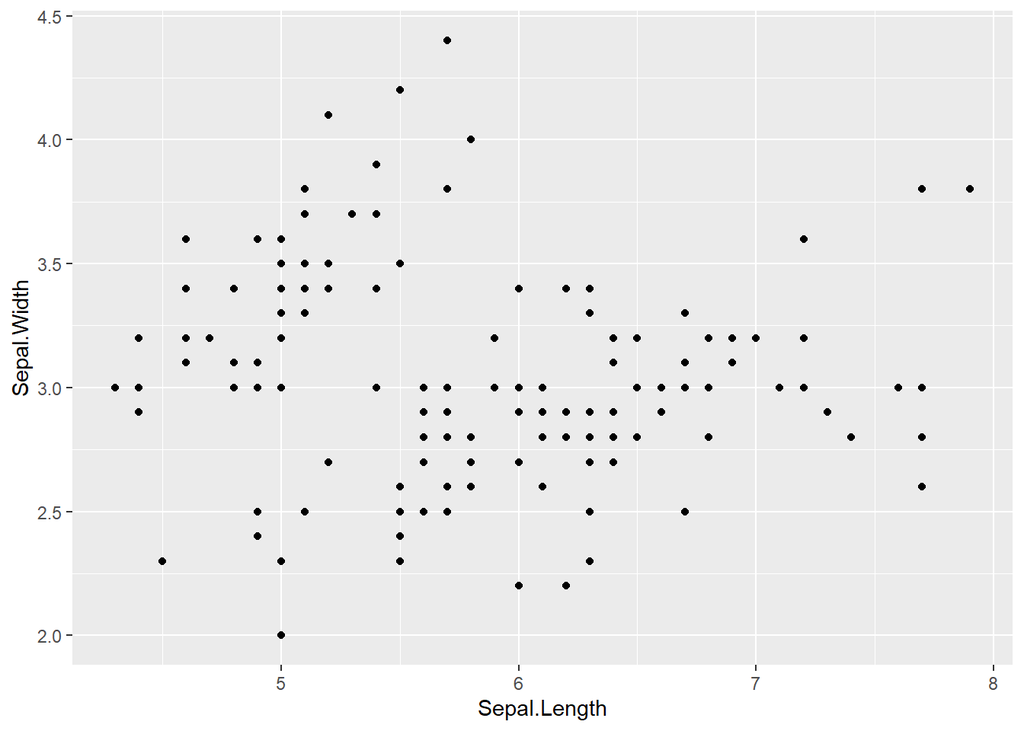

```r
# Gráfico de dispersão: Sepal.Length vs Sepal.Width
ggplot(data = iris, aes(x = Sepal.Length, y = Sepal.Width)) +
  geom_point()
```

## 1.3. Adicionar Mais Estéticas

Podemos mapear outras variáveis para estéticas adicionais.

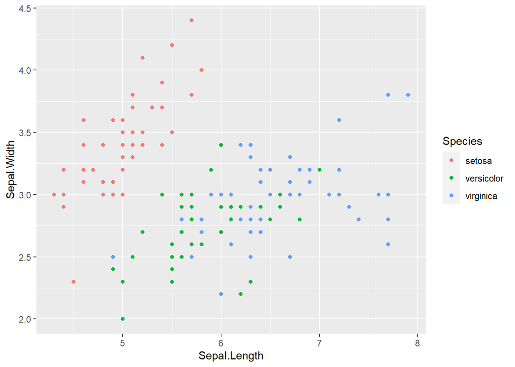

```r
# Mapear a cor dos pontos à variável Species
ggplot(data = iris, aes(x = Sepal.Length, y = Sepal.Width, color = Species)) +
  geom_point()
```

Agora, cada espécie tem uma cor diferente, o que nos ajuda a ver padrões.

## 1.4. Camadas Adicionais (+)

Podemos adicionar múltiplas camadas a um gráfico. Por exemplo, podemos adicionar uma linha de suavização.

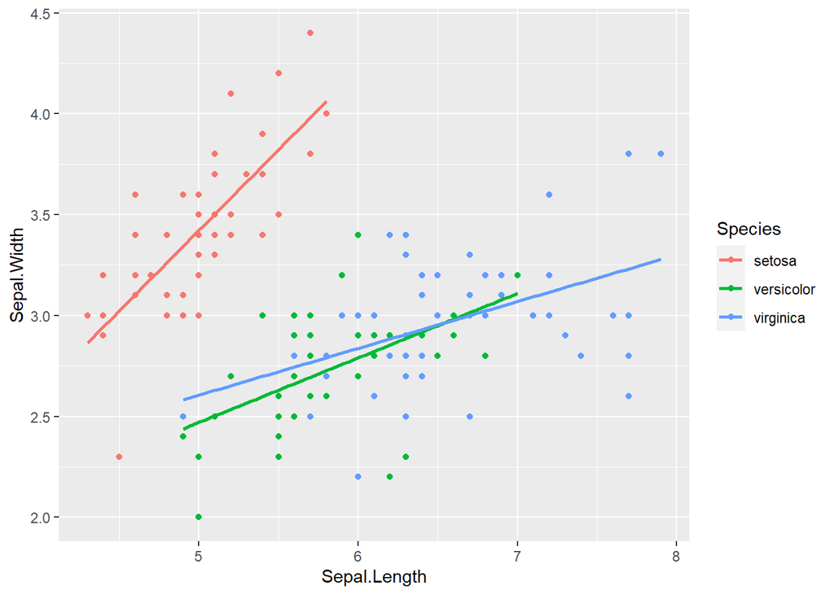

```r
# Adicionar uma linha de suavização (regressão) ao gráfico
ggplot(data = iris, aes(x = Sepal.Length, y = Sepal.Width, color = Species)) +
  geom_point() +
  geom_smooth(method = "lm", se = FALSE) # method="lm" para linha de regressão linear, se=FALSE remove a área de confiança
```

## 1.5. Personalização: Títulos e Rótulos

Podemos adicionar títulos, subtítulos e rótulos aos eixos usando a função labs().

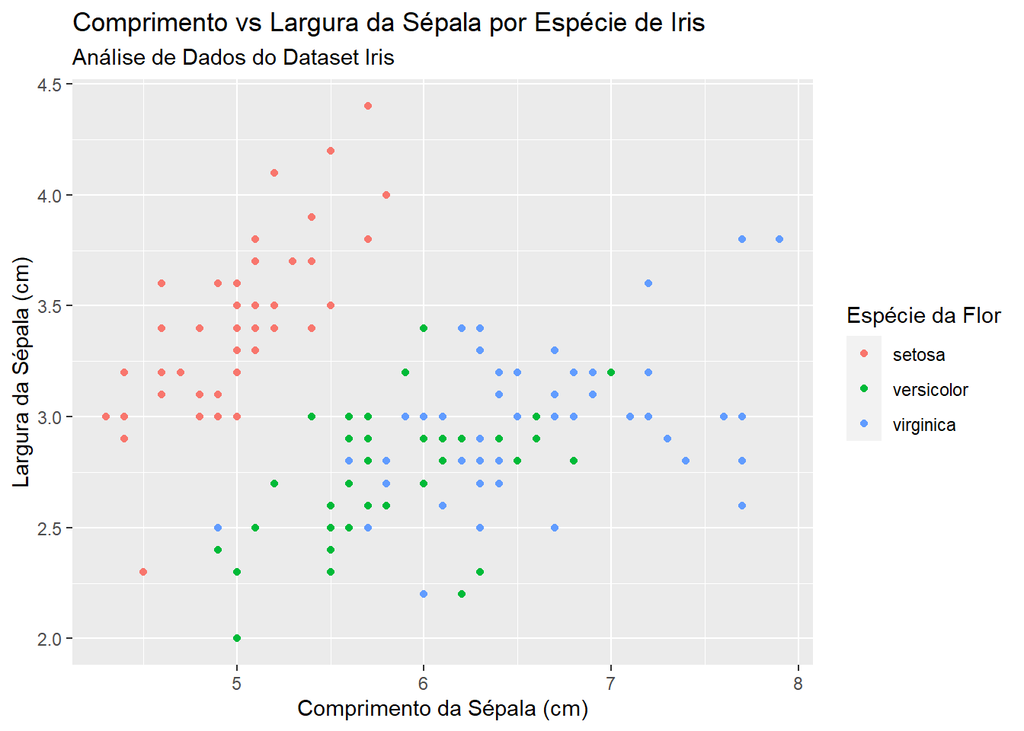

```r
ggplot(data = iris, aes(x = Sepal.Length, y = Sepal.Width, color = Species)) +
  geom_point() +
  labs(
    title = "Comprimento vs Largura da Sépala por Espécie de Iris",
    subtitle = "Análise de Dados do Dataset Iris",
    x = "Comprimento da Sépala (cm)",
    y = "Largura da Sépala (cm)",
    color = "Espécie da Flor" # Rótulo para a legenda de cor
  )
```

## 1.6. Salvar um Gráfico

Para salvar o gráfico, podemos atribuí-lo a um objeto e depois usar ggsave().

```r
meu_primeiro_grafico <- ggplot(data = iris, aes(x = Sepal.Length, y = Sepal.Width, color = Species)) +
  geom_point() +
  labs(title = "Comprimento vs Largura da Sépala da Sépala")

# Salvar como PNG
# ggsave("meu_grafico_iris.png", plot = meu_primeiro_grafico, width = 8, height = 6, dpi = 300)
# Salvar como PDF
# ggsave("meu_grafico_iris.pdf", plot = meu_primeiro_grafico, width = 8, height = 6)
```

**Parabéns!** Já conhecem os fundamentos da gramática dos gráficos com ggplot2!